# Lesson 9: Adaptation of Exploration 2.2 Strawberry Storage

by Anny-Claude Joseph

Last compiled on 16 September, 2021

**Background**: Researchers are interested in testing the potential effect of changing the composition of the air in which strawberries are stored. Five clamshells were randomly assigned to be stored in regular air and five clamshells were randomly assigned to be stored in a modified air. After two days of refrigeration in one of the two different atmospheres, the strawberries were then left at room temperature in regular air for two more days. The firmness of the strawberries was then measured by the force (measured in newtons, N) needed for a probe to pierce the exterior of the strawberry.Five clamshells were randomly assigned to a “control” condition which measured the strawberries immediately.

```r
## Load package(s) and data

library(tidyverse)

strawberry.dat <- read.table('C:/Users/annyclaude.joseph/Desktop/MA376/StrawberryStorageRCBD.txt', header = TRUE)

# Tasks:
# a) Confirm that data are in long format
# b) Verify that categorical variables are 'factors'. If not, change to factors.

view(strawberry.dat)
class(strawberry.dat$Storage)
```

```
## [1] "character"
```

```r
class(strawberry.dat$Variety)
```

```
## [1] "character"
```

```r
strawberry.dat <- strawberry.dat %>% mutate(Storage = factor(Storage),
                                  Variety = factor(Variety))
```

PPT 3: Ask the classification of the variables

1. Identify the experimental units in this study. Clamshells. Treatment was applied to clamshells not individual strawberries

PollEV 1 & 2

PPT 4: Sources of variation diagram

2. Looking at the summary statistics, does the storage method appear to explain some of the variability in the firmness levels? Explain.

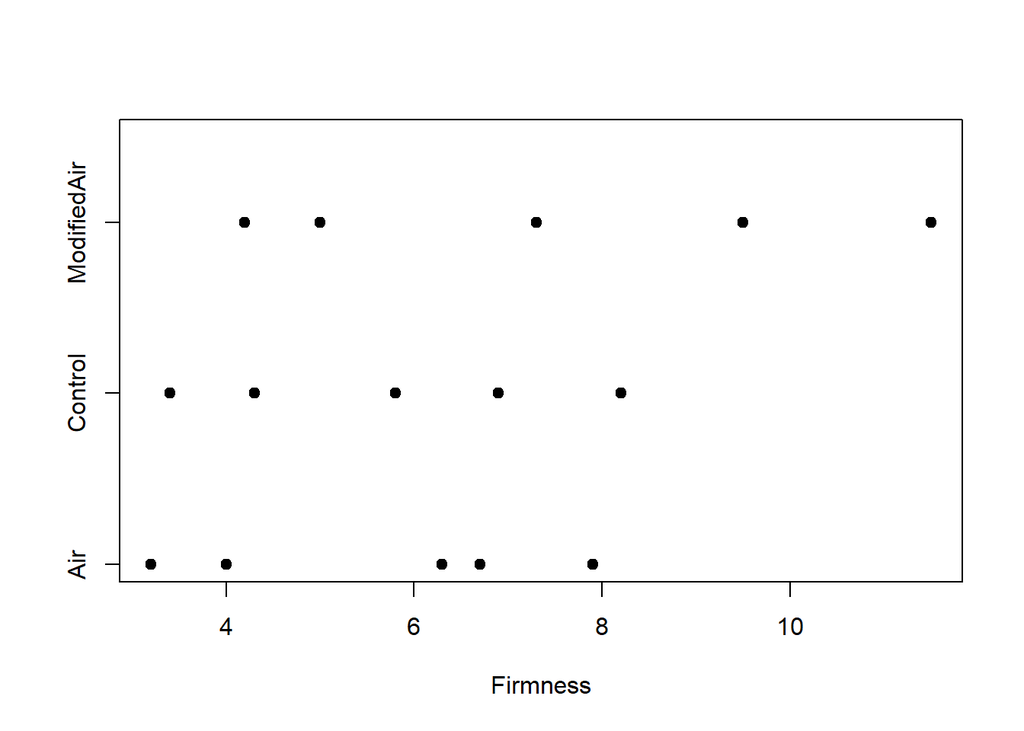

```r
# Strip chart of firmness by storage method
stripchart(strawberry.dat$Firmness~strawberry.dat$Storage, pch = 19, method = 'stack', vertical = FALSE, xlab='Firmness')
```

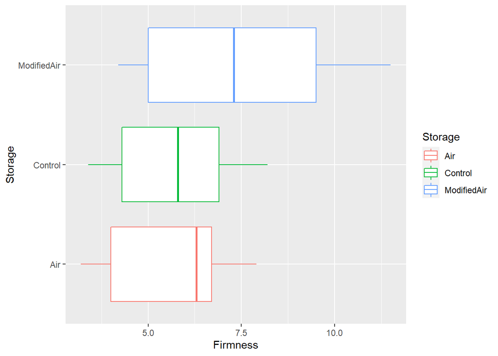

```r
# Boxplot of firmness vs storage
strawberry.dat %>% ggplot(aes(x=Firmness, y=Storage, color =Storage)) + geom_boxplot()
```

```r
# For each storage method calculate: mean, standard deviation, & number of observations
strawberry.dat %>% group_by(Storage) %>% summarise(Mean=mean(Firmness),SD = sd(Firmness),n())
```

|  | Storage | Mean | SD | n() |
| --- | --- | --- | --- | --- |
| 1 | Air | 5.62 | 1.956272 | 5 |
| 2 | Control | 5.72 | 1.933132 | 5 |
| 3 | ModifiedAir | 7.50 | 3.048770 | 5 |

3. What statistical test is appropriate to answer this research question? ANOVA
4. Express the null and alternative hypotheses in words then conduct an ANOVA to test these hypotheses. PollEV3: Alternative hypotheses

PPT 5: Hypotheses

```r
one_var.aov <- aov(Firmness ~ Storage, data = strawberry.dat)
summary(one_var.aov)
```

```
##             Df Sum Sq Mean Sq F value Pr(>F)
## Storage      2  11.19   5.594   0.995  0.398
## Residuals   12  67.44   5.620
```

5. PollEV4 How much variation in firmness values is explained by the storage method?

PPT 6: Partitioning SST

6. PollEV5 Suggest some possible explanations for finding an insignificant result here.

Rather than limiting themselves to one type of strawberry, the researchers decided to include five different varieties of strawberries in the study allowing them to generalize to a more diverse population of strawberries. Suspecting that different varieties of strawberries have different firmness ratings, the researchers opted to take into account strawberry variety (block on variety). In this way the variation explained by variety will be accounted for in the analysis by removing it from the unexplained variation.(stress that strawberry variety is not of interest in the research question it possibly explains some of the variation in firmness- it is a nuisance)

PPT 7: Updating sources of variation diagram

7. Looking at the summary statistics, do the data confirm or refute the researchers’ prediction that different strawberry varieties tend to have different firmness ratings? Is there a strawberry variety that tends to have very low firmness? Very high?

```r
# For each variety calculate: mean, standard deviation, & number of observations
strawberry.dat %>% group_by(Variety) %>% summarise(Mean=mean(Firmness),SD = sd(Firmness),n())
```

|  | Variety | Mean | SD | n() |
| --- | --- | --- | --- | --- |
| 1 | Allstar | 7.700000 | 1.5620499 | 3 |
| 2 | Bounty | 4.433333 | 0.5131601 | 3 |
| 3 | Kent | 6.466667 | 0.7637626 | 3 |
| 4 | Selva | 9.200000 | 1.9974984 | 3 |
| 5 | Vesper | 3.600000 | 0.5291503 | 3 |

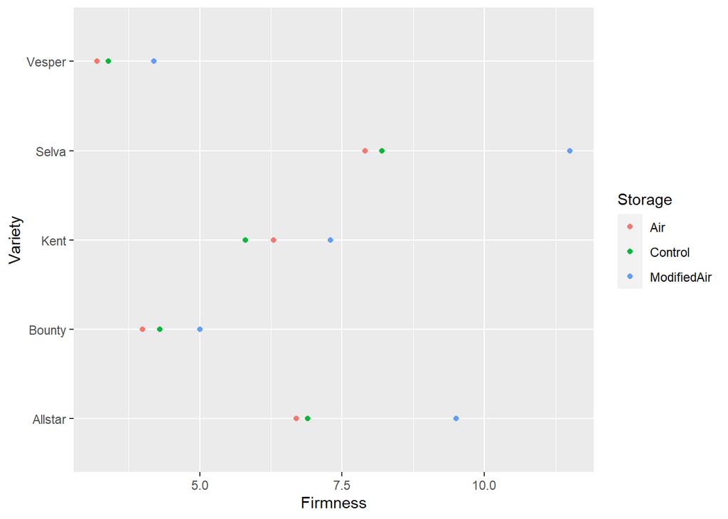

```r
# Scatter plot of firmness vs variety. Color each observation by the storage method
strawberry.dat %>% ggplot(aes(x=Firmness, y=Variety, color =Storage)) + geom_point()
```

8. PollEV6 Looking at the graph, do you think the storage method effect will be statistically significant after adjusting for variety? Explain your reasoning.

#### Randomized Complete Block Design

**What actually happened?** Samples of harvested Allstar strawberries were randomly placed into three clamshells and each clamshell was then randomly assigned to one of the three storage methods. This procedure was implemented for the four remaining strawberry varieties, as well. This restricted random assignment guarantees that there is one clamshell of each variety for each storage method.

PPT 8: Picture of randomization (top of page 167)

PPT 9: Then ask ‘In this example, what are the blocks?’

PollEV7

We need to reconsider our analysis so that it reflects the study design that was used.

**Theory-based Two-variable ANOVA**

9. Modify the analysis to consider blocking. Express the null and alternative hypotheses in words.PPT 10:

```r
# Two-variable ANOVA
two_var.aov <- aov(Firmness ~ Storage + Variety, data = strawberry.dat)
summary(two_var.aov)
```

```
##             Df Sum Sq Mean Sq F value   Pr(>F)
## Storage      2  11.19   5.594   11.40  0.00455 **
## Variety      4  63.51  15.878   32.36 5.47e-05 ***
## Residuals    8   3.93   0.491
## ---
## Signif. codes:  0 '***' 0.001 '**' 0.01 '*' 0.05 '.' 0.1 ' ' 1
```

10. What percentage of the variation in the response is due to the blocking variable and what percentage is due to the storage method? What does this say about the importance of this blocking variable in this study?

PPT 11: Partitioning SST

11. Recall that theory-based approaches require certain validity conditions to be met. Comment on how the analysis you just conducted meets the validity conditions by evaluating the three conditions listed in the Validity conditions box on page 163. PPT 12: Validity Conditions

```r
library(ggResidpanel)
```

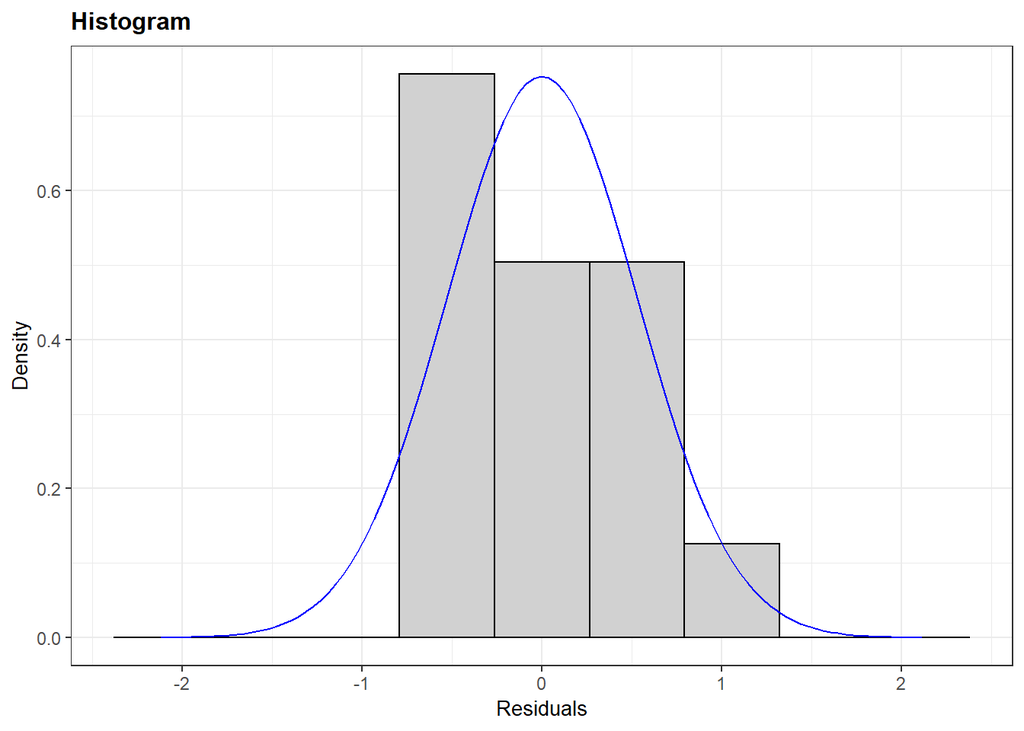

```r
two_var.mod <- lm(Firmness ~ Storage + Variety, data = strawberry.dat)
resid_panel(two_var.mod, plots= c('hist'), bin=9)
```

12. Summarize the conclusions you would draw from this study, including generalizability and causation (for both the method and the variety).What do you conclude after analyzing the block-adjusted F-statistic?

#### (Re)-read Analysis 2 and Analysis 3 on page 168-169. Pay attention to changes in the impact each analysis approach has on the F statistic.

### References

Nathan Tintle et al.(2019). Intermediate Statistical Investigations for U.S. Military Academy at West Point.